# U.S. Medical Insurance Costs By Ninh Nguyen

Goals:  
1) Find out the average age of the patients in the dataset.  
2) Analyze where a majority of the individuals are from.  
3) Look at the different costs between smokers vs. non-smokers.  
4) Figure out what the average age is for someone who has at least one child in this dataset.

The insurance data comes from the file "insurance.csv" which consists of 1338 observations of 7 variables.

Variable Descriptions:

age: age in years  
sex: male or female  
bmi: body mass index  
children: do they have children? (number of children)  
smoker: do they smoke? (yes or no)  
region: where the person is located (eg., southwest)  
charges: the insurance cost for the individual

## 1) The average age of the patients in the dataset.

```python
# import csv module
# reading the csv file after conversion to dictionary
import csv

with open('insurance.csv') as insurance:
    insurance_reader = csv.DictReader(insurance)
    for i in insurance_reader:
        print(i)
```

[output not shown]

[output cut: 1283 more lines]

[output not shown]

```python
# pandas and seaborn modules imported

import pandas as pd
import seaborn as sns
```

```python
# reading csv file

insurance = pd.read_csv('insurance.csv')
insurance
```

|  | age | sex | bmi | children | smoker | region | charges |
| --- | --- | --- | --- | --- | --- | --- | --- |
| 0 | 19 | female | 27.900 | 0 | yes | southwest | 16884.92400 |
| 1 | 18 | male | 33.770 | 1 | no | southeast | 1725.55230 |
| 2 | 28 | male | 33.000 | 3 | no | southeast | 4449.46200 |
| 3 | 33 | male | 22.705 | 0 | no | northwest | 21984.47061 |
| 4 | 32 | male | 28.880 | 0 | no | northwest | 3866.85520 |
| ... | ... | ... | ... | ... | ... | ... | ... |
| 1333 | 50 | male | 30.970 | 3 | no | northwest | 10600.54830 |
| 1334 | 18 | female | 31.920 | 0 | no | northeast | 2205.98080 |
| 1335 | 18 | female | 36.850 | 0 | no | southeast | 1629.83350 |
| 1336 | 21 | female | 25.800 | 0 | no | southwest | 2007.94500 |
| 1337 | 61 | female | 29.070 | 0 | yes | northwest | 29141.36030 |

1338 rows × 7 columns

```python
# examining number of observations and variable types

insurance.shape
```

```
(1338, 7)
```

```python
# selecting the 'age' variable

insurance['age']
```

```
0       19
1       18
2       28
3       33
4       32
        ..
1333    50
1334    18
1335    18
1336    21
1337    61
Name: age, Length: 1338, dtype: int64
```

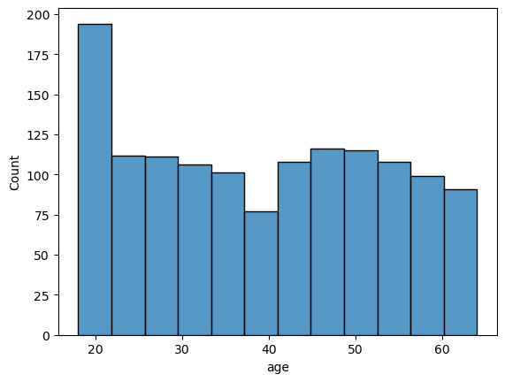

```python
# plotting a histogram of the age variable

age = sns.histplot(x = 'age', data = insurance)
```

```python
# describing the age variabe to find the average patient age

insurance['age'].describe()
```

```
count    1338.000000
mean       39.207025
std        14.049960
min        18.000000
25%        27.000000
50%        39.000000
75%        51.000000
max        64.000000
Name: age, dtype: float64
```

The average patient age is 39.

## 2) Where a majority of the individuals are from.

```python
# using the max function to find the top region

insurance['region'].max()
```

```
'southwest'
```

## 3) The different costs between smokers vs. non-smokers.

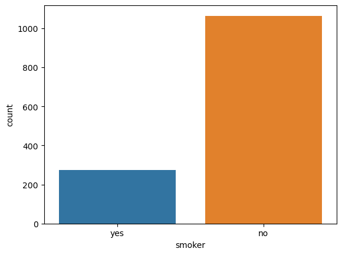

```python
count = sns.countplot(x = 'smoker', data = insurance)
```

```python
insurance['smoker'].value_counts()
```

```
no     1064
yes     274
Name: smoker, dtype: int64
```

```python
insurance['smoker'].describe()
```

```
count     1338
unique       2
top         no
freq      1064
Name: smoker, dtype: object
```

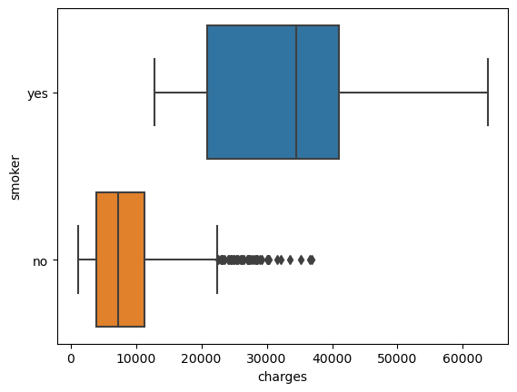

```python
charges = sns.boxplot(x = 'charges', y = 'smoker', data = insurance)
```

Non-smokers incur less insurance costs than smokers.

```python
insurance['charges'].describe()
```

```
count     1338.000000
mean     13270.422265
std      12110.011237
min       1121.873900
25%       4740.287150
50%       9382.033000
75%      16639.912515
max      63770.428010
Name: charges, dtype: float64
```

## 4) The average age for someone who has at least one child in this dataset.

```python
insurance['age'].describe()
```

```
count    1338.000000
mean       39.207025
std        14.049960
min        18.000000
25%        27.000000
50%        39.000000
75%        51.000000
max        64.000000
Name: age, dtype: float64
```

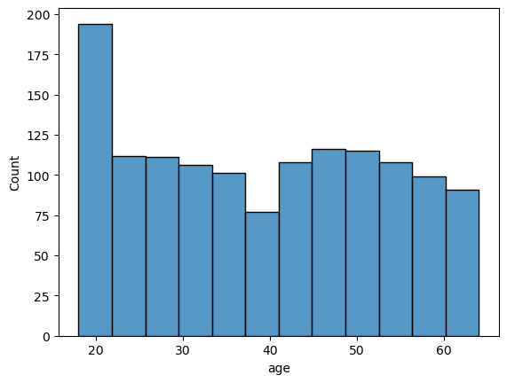

```python
age = sns.histplot(x = 'age', data = insurance)
```

```python
insurance['children'].describe()
```

```
count    1338.000000
mean        1.094918
std         1.205493
min         0.000000
25%         0.000000
50%         1.000000
75%         2.000000
max         5.000000
Name: children, dtype: float64
```

```python
insurance['children'].value_counts()
```

```
0    574
1    324
2    240
3    157
4     25
5     18
Name: children, dtype: int64
```

```python
insurance['age'].mean()/insurance['children'].mean()
```

```
35.808191126279866
```